# Met500 Plots

#loading in rsd and formatting SE object

```r
sumexp3 <- sumexp
assay(sumexp3) <- log2(cpm(assay(sumexp3)) + 1)
```

```r
#rid of dups
plottingMET_data <- data.frame(subject = sumexp3$submitted_subject_id,
                           sample = sumexp3$Run,
                           body = sumexp3$BODY_SITE,
                           gene_expression = colSums(assays(sumexp3)$counts),
                           tumor = sumexp3$PRIMARY_METASTATIC_TUMOR,
                           prim_loc = sumexp3$PRIMARY_TUMOR_LOCATION,
                           age = sumexp3$Age,
                           sex = sumexp3$Gender,
                           hist = sumexp3$HISTOLOGICAL_TYPE,
                           library = sumexp3$LibrarySelection)

#got rid of duplicate runs (all information is same in row exept total gene expression)
plottingMETFilt <- plottingMET_data[!duplicated(plottingMET_data[c("subject", "body","tumor","prim_loc","age","sex","hist")]), ]
rows <- rownames(plottingMETFilt)

plottingMETFilt <- plottingMETFilt %>%
  filter(tumor != "NA", prim_loc != "?")

plottingMETFilt$prim_loc <- factor(plottingMETFilt$prim_loc)
plottingMETFilt$age <- as.integer(plottingMETFilt$age)

#updatin no dups for sumexp
sumexp <- sumexp[ ,rows]
sample_info <- as.data.frame(colData(sumexp)@listData)
```

```r
library(tidySummarizedExperiment)
sumexp3 <- sumexp3 %>%
  group_by(PRIMARY_TUMOR_LOCATION)
```

```
tidySummarizedExperiment says: A data frame is returned for independent data analysis.
```

```r
sumexp3<- sumexp3 %>%
  filter(.sample %in% rows)

sumexp3$.sample <- factor(sumexp3$.sample, levels = unique(sumexp3$.sample[order(sumexp3$Gender)]))
sumexp3$.sample <- factor(sumexp3$.sample, levels = unique(sumexp3$.sample[order(sumexp3$PRIMARY_TUMOR_LOCATION)]))
```

Summary of Data: * 1141 samples, not paired * 1070 Metastatic sites and 71 Primary sites (no matched samples) * 1132 subjects * focus on just Metastatic sites

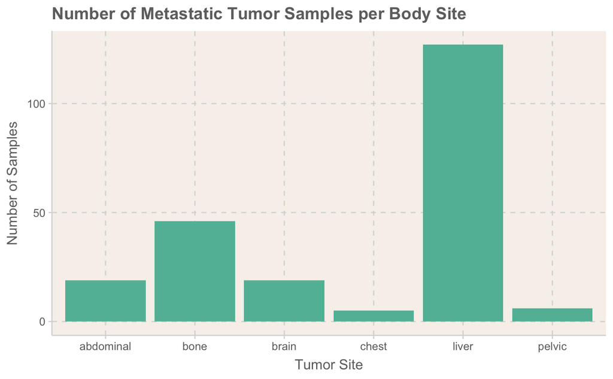

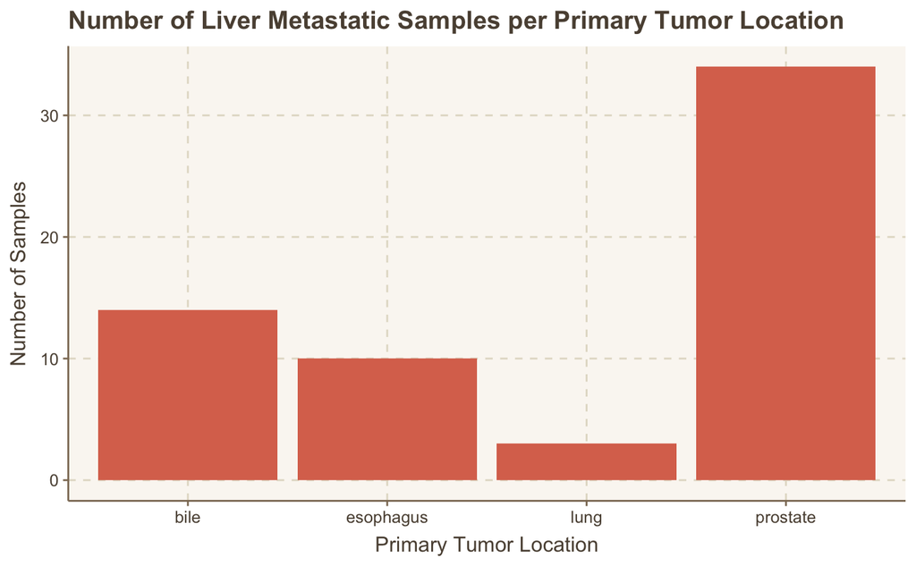

```r
ggthemr("dust")
plottingMETFilt %>%
  filter(!tumor %in% c("NA","Primary"),
         sex == "M",
         body == "liver",
         prim_loc %in% c("bile", "esophagus", "prostate", "breast", "lung")) %>%
  ggplot(aes(x = prim_loc)) +
  geom_bar()+
  xlab("Primary Tumor Location") +
  ylab("Number of Samples") +
  ggtitle("Number of Liver Metastatic Samples per Primary Tumor Location")

ggsave('barplotGENDEr_liver_.png', width = 10, height = 10)
```

[output not shown]

[output cut: 491 more lines]

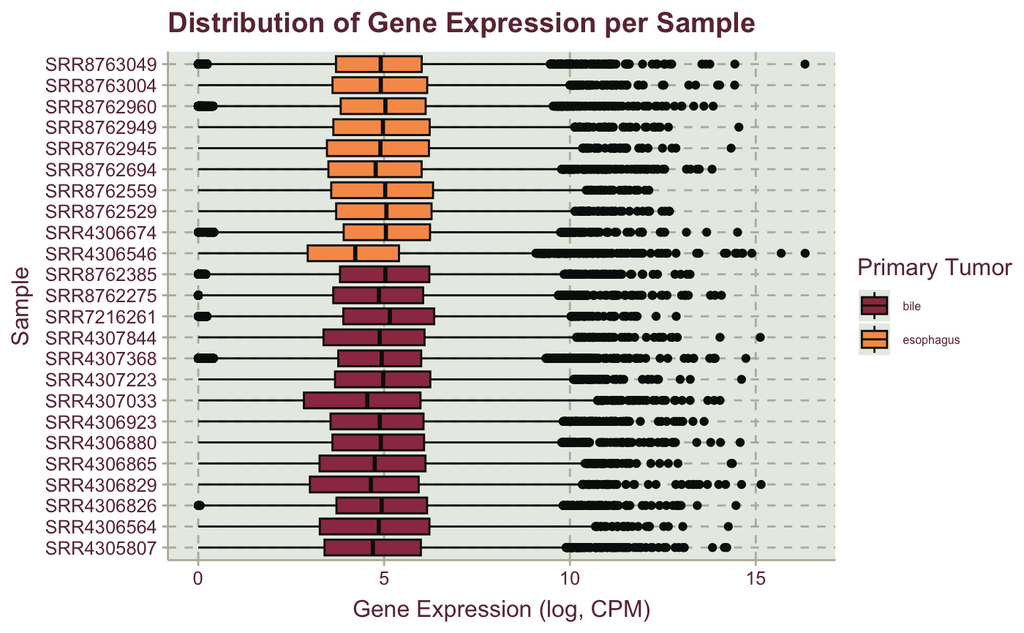

```r
ggthemr("grape")
sumexp3$.sample <- factor(sumexp3$.sample, levels = unique(sumexp3$.sample[order(sumexp3$PRIMARY_TUMOR_LOCATION)]))


sumexp3 %>%
filter(BODY_SITE == "liver",
      Gender == "M",
       PRIMARY_TUMOR_LOCATION %in% c("bile", "esophagus"),
       PRIMARY_METASTATIC_TUMOR == "Metastatic") %>%
 ggplot(aes(x = .sample, y = counts, fill = PRIMARY_TUMOR_LOCATION)) +
  geom_boxplot()+
  ggtitle("Distribution of Gene Expression per Sample ")+
  xlab("Sample") +
  ylab("Gene Expression (log, CPM)") +
  labs(fill = "Primary Tumor") +
  theme(legend.text = element_text(size = 6))+
  coord_flip()

ggsave('boxplot_liver_GE.png', width = 8, height = 10)
```

**Fig 2. Looking at gene expression in counts per million to account for size and its distribution for each of the liver metastatic body site samples. Filled by primary tumor location either bile ducts or esophagus. We see ever so slightly esophagus have a little higher median gene expression, is it significant?**

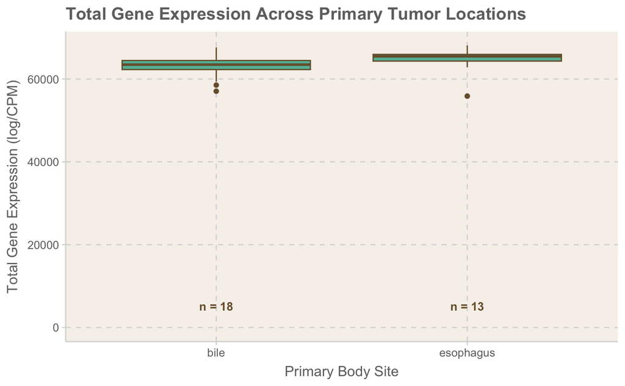

```r
ggthemr("light")
plottingMETFilt %>%
  filter(!tumor %in% c("NA","Primary"),
         body == "liver",
         prim_loc %in% c("bile", "esophagus")) %>%
  ggplot(aes(x = prim_loc, y = gene_expression)) +
  geom_boxplot(position = "dodge") +
  labs(x = "Primary Body Site", y = "Total Gene Expression (log/CPM)", color = "Tumor Type") +
  ggtitle("Total Gene Expression Across Primary Tumor Locations")+
  geom_text(data = plottingMETFilt %>%
              filter(!tumor %in% c("NA","Primary"),body == "liver",prim_loc %in% c("bile", "esophagus")) %>%
              group_by(prim_loc) %>%
              summarise(top = max(gene_expression),
                        n=n()),
            aes(x= prim_loc, y=0, label= paste0("n = ", n)),
            size = 3.5, fontface = "bold", vjust = -2
             )

ggsave('boxplotTOTAL_liver_.png', width = 8, height = 8)
```

**Fig 3. Total gene expression in counts per million (to account for size) and log transformed (for visualization purposes) for all liver metastatic tumors samples. It is comparing the expression between from bile vs esophagus primary tumors and esophagus is slightly higher. They do have comparable sample sizes (31 total samples for this subset).**

```r
ggthemr(palette = "light")
sumexp3 %>%
  filter(BODY_SITE == "liver",
      Gender == "M",
       PRIMARY_TUMOR_LOCATION %in% c("bile", "esophagus"),
       PRIMARY_METASTATIC_TUMOR == "Metastatic") %>%
  ggplot(aes(x = counts, color = PRIMARY_TUMOR_LOCATION)) +
  geom_density() +
  xlab("Gene Count (CPM/log)")
  ggtitle("Gene Counts per Body Site") +
  theme(legend.title = element_text(size = 8),
        legend.text = element_text(size = 8))

ggsave('density_plot_Met.png', width = 7, height = 5)
```

[output not shown]

#PCA just looking at bile and esophagus prim tumors

```r
samp_info_absMET <- sample_info %>%
  filter(BODY_SITE == "liver",
         Gender == "M",
         PRIMARY_METASTATIC_TUMOR == "Metastatic",
         PRIMARY_TUMOR_LOCATION %in% c("bile", "esophagus")) %>%
  mutate(Year = ifelse(substr(create_date, 1, 4) == "2016", "2016", "2019"))
keep <- samp_info_absMET$Run
sumexpAbs <- sumexp[ ,keep]
sumexpAbs$create_date <- samp_info_absMET$Year

#dds is filtered for this subset question with only primary tumor locations bein bile and esophagus
assays(sumexpAbs)$counts <- round(assays(sumexpAbs)$counts)
dds2 <- DESeqDataSet(sumexpAbs, design = ~ PRIMARY_TUMOR_LOCATION)
```

```
Warning: some variables in design formula are characters, converting to factors
```

```r
dds2$PRIMARY_TUMOR_LOCATION <- factor(dds2$PRIMARY_TUMOR_LOCATION, levels = c("bile","esophagus"))

vsd2 <- vst(dds2, blind = TRUE)
```

```r
all_prim_loc <- sample_info %>%
  filter(Gender == "M",
         BODY_SITE == "liver",
         PRIMARY_METASTATIC_TUMOR == "Metastatic",
         PRIMARY_TUMOR_LOCATION %in% c("bile", "esophagus")) %>%
  mutate(Year = ifelse(substr(create_date, 1, 4) == "2016", "2016", "2019"),
         Age = cut(Age, breaks = c(0, 19, 39, 59, 79, 93),
                    labels = c("0-19", "20-39", "40-59", "60-79", "80-93")))

all_prim_loc$Year <- factor(all_prim_loc$Year)
all_prim_loc$PRIMARY_TUMOR_LOCATION <- factor(all_prim_loc$PRIMARY_TUMOR_LOCATION,
                                              levels = c("bile","esophagus"))
#which samples to keep in SE
keep <- all_prim_loc$Run
sumexpALL <- sumexp[ , keep]
sumexpALL <- sumexpALL %>%
  mutate(Year = ifelse(substr(create_date, 1, 4) == "2016", "2016", "2019"),
         Age = cut(Age, breaks = c(0, 19, 39, 59, 79, 93),
                    labels = c("0-19", "20-39", "40-59", "60-79", "80-93")))

sumexpALL$Age <- factor(sumexpALL$Age)
#dds object
assays(sumexpALL)$counts <- round(assays(sumexpALL)$counts)
dds3 <- DESeqDataSet(sumexpALL, design = ~ Year + PRIMARY_TUMOR_LOCATION )
```

```
Warning: some variables in design formula are characters, converting to factors
```

#pvca plot

[figure not shown]

```r
#estimating dispersion
dds2 = estimateDispersions(dds2)
```

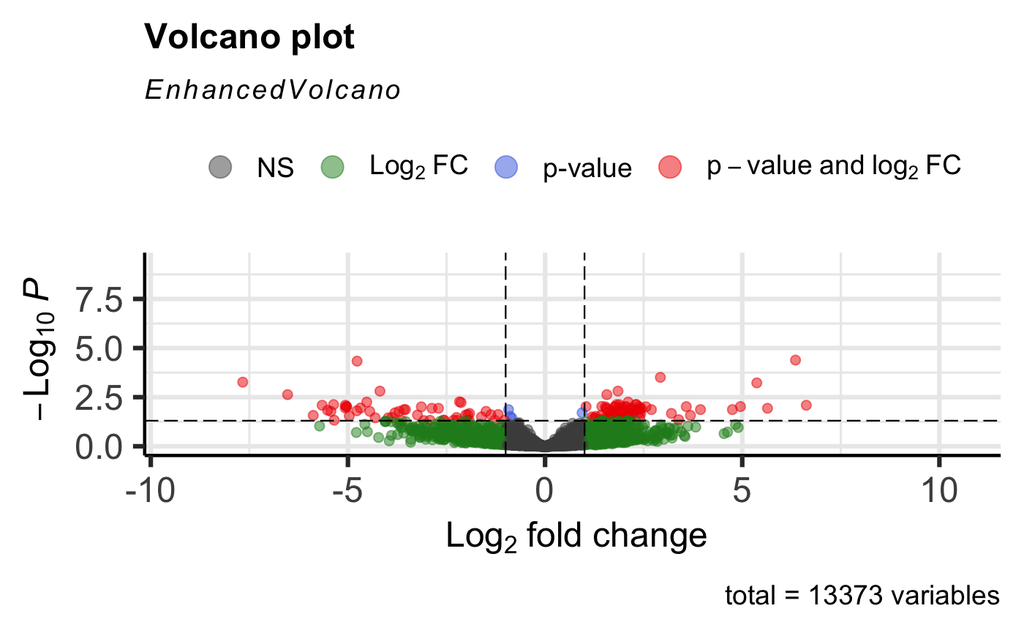

```r
#select = c("CDCA5","HMGA1", "BRI3BP", "UBE2S", "KIAA0903", "TSPAN5", "FGFR4", "GK5","GASK1A", "ADPRM","MED12L","MYH11","ACTG2", "PRDM8", "MED12L", "ZNF594", "PRDM8")
#select_cool <- c("GK5", "UBE2S", "CDCA5", "BIRC5", "TK1")
select <- c("")
ggthemr("grape")

EnhancedVolcano(toptable = sigRes_all,
                x = "log2FoldChange",
                y = "padj",
                lab = sigRes_all$external_gene_name,
                selectLab = select,
                pCutoff = .05,
                FCcutoff = 1)

ggsave('Met_volcano_plot.png', width = 15, height = 10)
```

```r
NA
NA
```

**Fig 5. Shows genes in red that both have “significant” differences between the two and have distinct unregulated or downregulated log fold changes (how much gene is expressed).**

```r
#getting sample info
DDS2sample_info <- as.data.frame(colData(dds2))

#getting genes
genes.kept <- sigRes4[sigRes4$external_gene_name %in% select_cool, ]
genes.kept <- rownames(genes.kept)

#getting counts/treatment/gene names situated
count.table <- counts(dds2, normalized=T)[genes.kept, ]
cols <- colnames(count.table)
DDS2sample_info <- DDS2sample_info %>%
  filter(rownames(DDS2sample_info) %in% cols)
colnames(count.table) = paste(DDS2sample_info$PRIMARY_TUMOR_LOCATION, colnames(count.table), sep = " : ")

#gene id names
count.table <- count.table %>%
  as.data.frame() %>%
  rownames_to_column(var = "gene")
count.table <-  left_join(count.table, gene_info, by = c("gene" = "GENEID"))
rownames(count.table) <- count.table$external_gene_name
count.table <- count.table[,-33]
count.table <- count.table[,-1]

#heatmap z scores
count.table.z <- t(apply(count.table, 1, scale))
colnames(count.table.z) <- colnames(count.table)

#colors

myCols2 <- c("bile : SRR4307033", "bile : SRR4307364","bile : SRR4306923","bile : SRR4307368","esophagus : SRR8762949","esophagus : SRR8762625","esophagus : SRR8762960","esophagus : SRR8763004")
row_idx2 <- which(colnames(count.table.z) %in% myCols2)


fontcolors <- rep('grey', ncol(count.table.z))
fontcolors[11] <- "black" #esophagus
fontcolors[12] <- "#0000FF" #bile
fontcolors[14] <- "#0000FF"  #bile
fontcolors[15] <- "#0000FF" #bile

fontcolors[23] <- "black" #esophagus
fontcolors[11] <- "#0000FF" #bile
fontcolors[27] <- "black" #esophagus
fontcolors[28] <- "black" #esophagus
fontcolors[29] <- 'black' #esophagus

 fontcolors_rows <- rep('black', nrow(count.table.z))
 fontcolors_rows[1] <- "#0000FF"
 fontcolors_rows[2] <- "#0000FF"
 fontcolors_rows[3] <- "#0000FF"
 fontcolors_rows[5] <- "black"
 fontcolors_rows[4] <- "#0000FF"



#heatmap
h4 <- Heatmap(count.table.z, cluster_rows = T, column_labels = colnames(count.table.z), name = "Z-score", row_labels = rownames(count.table.z),
              column_names_gp = gpar(col = fontcolors, fontface = "bold"),
             row_names_gp = gpar(col = fontcolors_rows, fontface = "bold"))
```

#GSEA

```r
#ordered results table
sigResall_gse <- sigRes_all %>%
  filter(!grepl("^ENSG",external_gene_name)) %>%
  rownames_to_column(var = "geneID")

#mading it not be versions
sigResall_gse <- sigResall_gse %>%
  mutate(geneID = str_replace(geneID,"\\..*$", ""))
rownames(sigResall_gse) <- sigResall_gse$geneID
sigResall_gse <- sigResall_gse[,-1]
```

```r
#gene list ordered by descending LFC
gene_list2 <- sigResall_gse$log2FoldChange
names(gene_list2) <- rownames(sigResall_gse)
gene <- names(gene_list2)
gene_list2 <- na.omit(gene_list2)
gene_list2 = sort(gene_list2,decreasing = TRUE)
gene_list2
```

```r
#running gsea
met_gse <- gseGO(gene_list2,
                    ont = "BP",
                    keyType = "ENSEMBL",
                    OrgDb = "org.Hs.eg.db",
                    eps = 1e-300)

new <- as.data.frame(met_gse)
```

```r
gseaplot(met_gse, geneSetID = 102, title = met_gse$Description[102])
ggsave('Met_gsea.png', width = 15, height = 10)
```

```r
library(enrichplot)
met_dis <- enricher(gene_list2,
                    org)
barplot(met_gse, showCategory = 10)
```

####NEW HEATMAP and GSEA

```r
#get list of all hallmark gene sets
library(msigdbr)
hs_msigdb_df <- msigdbr(species = "Homo sapiens")
head(hs_msigdb_df)

#keep only hallmark gene sets
hs_hallmark_df <- hs_msigdb_df %>%
  dplyr::filter(
    gs_cat == "H", # This is to filter only to the H curated gene sets
  )
head(hs_hallmark_df)
```

```r
entrez_vector <- mapIds(
  # Replace with annotation package for the organism relevant to your data
  org.Hs.eg.db,
  # The vector of gene identifiers we want to map
  keys = look_all$gene,
  # Replace with the type of gene identifiers in your data
  keytype = "ENSEMBL",
  # Replace with the type of gene identifiers you would like to map to
  column = "ENTREZID",
  # In the case of 1:many mappings, return the
  # first one. This is default behavior!
  multiVals = "first"
)
#get df of ensemble and entrez ids
gene_key_df <- data.frame(
  ensembl_id = names(entrez_vector),
  entrez_id = entrez_vector,
  stringsAsFactors = FALSE
) %>%
  dplyr::filter(!is.na(entrez_id))

#adding gene_key_df to our dataframe of diff expressed genes and universe

universe_df <- gene_key_df %>%
  dplyr::left_join(look_all, by = c("ensembl_id" = "gene"))

diff_df <- look_sig %>%
   dplyr::left_join(gene_key_df, by = c("gene" = "ensembl_id"))%>%
  dplyr::filter(!is.na(entrez_id))
```

[output not shown]

```r
#list of all genes in the needed gene sets
gene_sets <- ora_results$ID
#totlist of genesets
total_genelist <- hs_hallmark_df %>%
  filter(gs_name %in% gene_sets)

#get list for gsva
hallmarks_list <- split(
  total_genelist$entrez_gene, # The genes we want split into pathways
  total_genelist$gs_name # The pathways made as the higher levels of the list
)

#get vst expression
vst_df <- assay(vsd) %>%
  as.data.frame() %>% # Make into a data frame
  tibble::rownames_to_column("ensembl_id") %>%
  mutate(ensembl_id = str_replace(ensembl_id,"\\..*$", ""))
```

[output not shown]

```r
# First let's determine the gene means
gene_means <- rowMeans(mapped_df %>% dplyr::select(-ensembl_id, -entrez_id))

# Let's add this as a column in our `mapped_df`.
mapped_df <- mapped_df %>%
  # Add gene_means as a column called gene_means
  dplyr::mutate(gene_means) %>%
  # Reorder the columns so `gene_means` column is upfront
  dplyr::select(ensembl_id, entrez_id, gene_means, dplyr::everything())

filtered_mapped_df <- mapped_df %>%
  # Sort so that the highest mean expression values are at the top
  dplyr::arrange(dplyr::desc(gene_means)) %>%
  # Filter out the duplicated rows using `dplyr::distinct()`
  dplyr::distinct(entrez_id, .keep_all = TRUE)

sum(duplicated(filtered_mapped_df$entrez_id))
```

```
[1] 0
```

```r
filtered_mapped_matrix <- filtered_mapped_df %>%
  # GSVA can't the Ensembl IDs so we should drop this column as well as the means
  dplyr::select(-ensembl_id, -gene_means) %>%
  # We need to store our gene identifiers as row names
  tibble::column_to_rownames("entrez_id") %>%
  # Now we can convert our object into a matrix
  as.matrix()
```

```r
gsva_results <- gsva(
  filtered_mapped_matrix,
  hallmarks_list,
  method = "gsva",
  # Appropriate for our vst transformed data
  kcdf = "Gaussian",
  # Minimum gene set size
  min.sz = 15,
  # Maximum gene set size
  max.sz = 500,
  # Compute Gaussian-distributed scores
  mx.diff = TRUE,
  # Don't print out the progress bar
  verbose = FALSE
)
head(gsva_results)
```

```r
annot_df <- annot_df %>%
  column_to_rownames("Run")
```

[output not shown]

```r
library(pheatmap)
pheatmap<-pheatmap::pheatmap(
  gsva_results_order,
  annotation_col = annot_df, # Add metadata labels!
  show_colnames = FALSE, # Don't show sample labels
  fontsize_row = 12,
  cluster_col = F,
  main = "Heatmap of Samples and Gene Sets"
)


png("heatmapMET.png", res = 100, width = 2000, height =800)
```

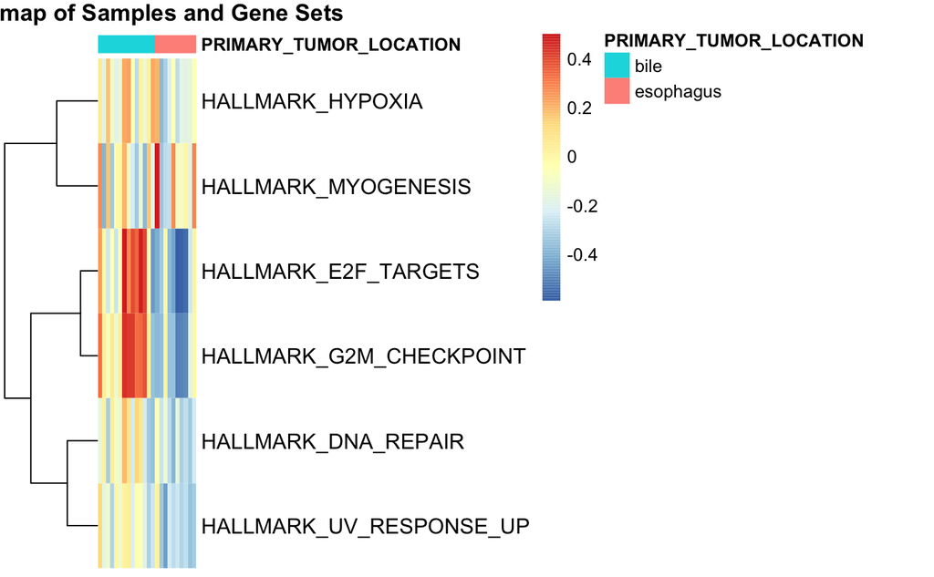

```r
print(pheatmap)
dev.off()
```